# Derivadas en R (Trabajo Final)

Rafael Rizo Badajoz, Julieta Vega Cruz y Monica Natalia Perez Espinosa

10/01/2021

###1. Activamos la libreria correspondiente para poder llevar acabo el ejercicio de derivadas

```r
library(Deriv) # Esta es nesesaria para hacer derivadas en R con la función Deriv
```

###2. Ocuparemos dos metodos, el primer método:

R puede realizar derivadas sin la necesidad de instalar librerías si utilizamos `expression` para crear nuestra función y posteriormente utilizamos `D` para obtener la derivada:

```r
f<-expression(x^6+8*x)
fprima<-D(f,"x")
fprima
```

```
## 6 * x^5 + 8
```

###3. Segundo método

Con la librería `Deriv`, tambien podemos hacer derivadas en R. Primero, utilizaremos `function` para crear nuestra función y posteriormente, utilizaremos `Deriv` para calcular la derivada:

```r
p<-function(x) x^2+3*x
pprima<-Deriv(p)
pprima
```

```
## function (x)
## 2 * x + 3
```

###4. Creando un dominio para nuestra función donde nos acercamos bastante a 0 pero no llegamos a este

```r
x<-seq(-6,6,0.01)
x
```

[output not shown]

[output cut: 86 more lines]

###5. Graficando nuestra función

Si deseamos hacer una gráfica de nuestra función y su derivada, tenemos que utilizar el segundo método:

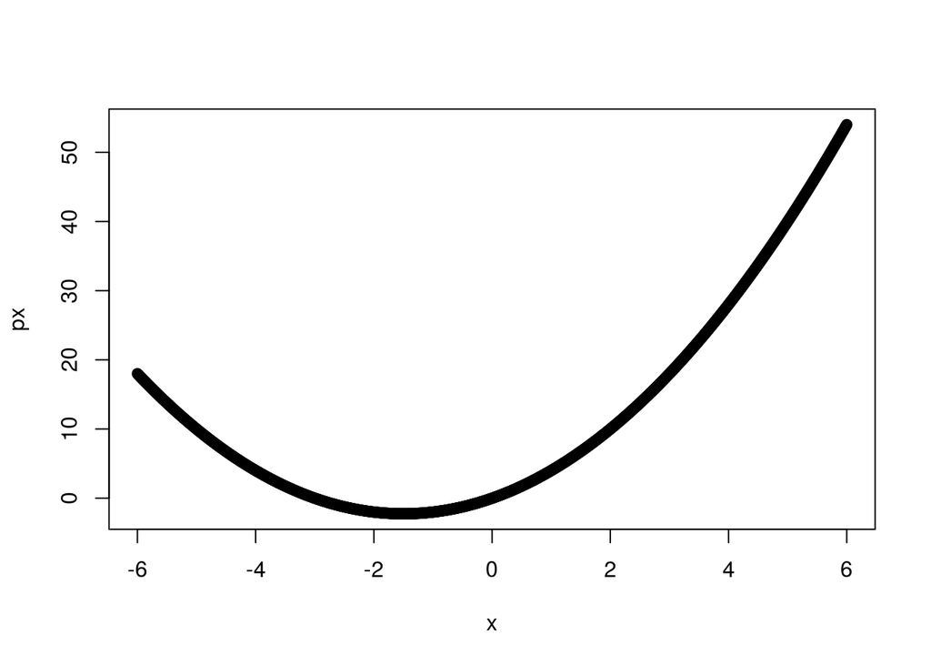

```r
px<-p(x)
plot(x,px)
```

### A continuación realizaremos una actividad de repaso para poder observar como funciona cada método

Calculamos la derivada con el primer metodo

#i(x)=x^6-3*x^5

```r
a<-expression(x^6-3*x^5)
aprima<-D(a,"x")
aprima
```

```
## 6 * x^5 - 3 * (5 * x^4)
```

Ahora utilizaremos el segundo metodo para obtener una derivada en R

#g(x)=x^2+2

```r
t<-function(x) (x^2+2)
tprima<-Deriv(t)
tprima
```

[output not shown]

Ahora graficaremos esta segunda

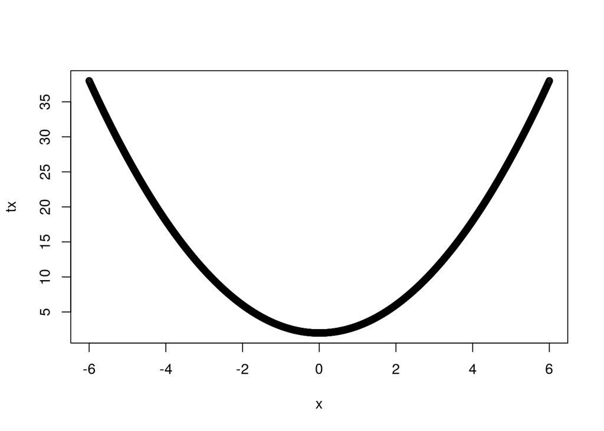

```r
tx<-t(x)
plot(x,tx)
```

A continuación un tutorial de como se puede realizar este ejercicio:

[video not shown]